# W3cubDocs

/Matplotlib 3.5

# matplotlib.lines.Line2D

**class*matplotlib.lines.Line2D(*xdata*, *ydata*, *linewidth=None*, *linestyle=None*, *color=None*, *marker=None*, *markersize=None*, *markeredgewidth=None*, *markeredgecolor=None*, *markerfacecolor=None*, *markerfacecoloralt='none'*, *fillstyle=None*, *antialiased=None*, *dash_capstyle=None*, *solid_capstyle=None*, *dash_joinstyle=None*, *solid_joinstyle=None*, *pickradius=5*, *drawstyle=None*, *markevery=None*, **kwargs)[[source]](https://github.com/matplotlib/matplotlib/blob/v3.5.1/lib/matplotlib/lines.py#L198-L1388)**

Bases: `matplotlib.artist.Artist`

A line - the line can have both a solid linestyle connecting all the vertices, and a marker at each vertex. Additionally, the drawing of the solid line is influenced by the drawstyle, e.g., one can create "stepped" lines in various styles.

Create a `Line2D` instance with *x* and *y* data in sequences of *xdata*, *ydata*.

Additional keyword arguments are `Line2D` properties:

| Property | Description |
| --- | --- |
| `agg_filter` | a filter function, which takes a (m, n, 3) float array and a dpi value, and returns a (m, n, 3) array |
| `alpha` | scalar or None |
| `animated` | bool |
| `antialiased` or aa | bool |
| `clip_box` | `Bbox` |
| `clip_on` | bool |
| `clip_path` | Patch or (Path, Transform) or None |
| `color` or c | color |
| `dash_capstyle` | `CapStyle` or {'butt', 'projecting', 'round'} |
| `dash_joinstyle` | `JoinStyle` or {'miter', 'round', 'bevel'} |
| `dashes` | sequence of floats (on/off ink in points) or (None, None) |
| `data` | (2, N) array or two 1D arrays |
| `drawstyle` or ds | {'default', 'steps', 'steps-pre', 'steps-mid', 'steps-post'}, default: 'default' |
| `figure` | `Figure` |
| `fillstyle` | {'full', 'left', 'right', 'bottom', 'top', 'none'} |
| `gid` | str |
| `in_layout` | bool |
| `label` | object |
| `linestyle` or ls | {'-', '--', '-.', ':', '', (offset, on-off-seq), ...} |
| `linewidth` or lw | float |
| `marker` | marker style string, `Path` or `MarkerStyle` |
| `markeredgecolor` or mec | color |
| `markeredgewidth` or mew | float |
| `markerfacecolor` or mfc | color |
| `markerfacecoloralt` or mfcalt | color |
| `markersize` or ms | float |
| `markevery` | None or int or (int, int) or slice or list[int] or float or (float, float) or list[bool] |
| `path_effects` | `AbstractPathEffect` |
| `picker` | float or callable[[Artist, Event], tuple[bool, dict]] |
| `pickradius` | float |
| `rasterized` | bool |
| `sketch_params` | (scale: float, length: float, randomness: float) |
| `snap` | bool or None |
| `solid_capstyle` | `CapStyle` or {'butt', 'projecting', 'round'} |
| `solid_joinstyle` | `JoinStyle` or {'miter', 'round', 'bevel'} |
| `transform` | unknown |
| `url` | str |
| `visible` | bool |
| `xdata` | 1D array |
| `ydata` | 1D array |
| `zorder` | float |

See `set_linestyle()` for a description of the line styles, `set_marker()` for a description of the markers, and `set_drawstyle()` for a description of the draw styles.

**contains(*mouseevent*)[[source]](https://github.com/matplotlib/matplotlib/blob/v3.5.1/lib/matplotlib/lines.py#L414-L482)**

Test whether *mouseevent* occurred on the line.

An event is deemed to have occurred "on" the line if it is less than `self.pickradius` (default: 5 points) away from it. Use `get_pickradius` or `set_pickradius` to get or set the pick radius.

**Parameters**

**mouseevent**`matplotlib.backend_bases.MouseEvent`**

**Returns**

**contains**bool**

Whether any values are within the radius.

**details**dict**

A dictionary `{'ind': pointlist}`, where *pointlist* is a list of points of the line that are within the pickradius around the event position.

TODO: sort returned indices by distance

**draw(*renderer*)[[source]](https://github.com/matplotlib/matplotlib/blob/v3.5.1/lib/matplotlib/artist.py#L724-L857)**

Draw the Artist (and its children) using the given renderer.

This has no effect if the artist is not visible (`Artist.get_visible` returns False).

**Parameters**

**renderer**`RendererBase` subclass.**

#### Notes

This method is overridden in the Artist subclasses.

**drawStyleKeys*=['default', 'steps-mid', 'steps-pre', 'steps-post', 'steps']**

**drawStyles*={'default': '_draw_lines', 'steps': '_draw_steps_pre', 'steps-mid': '_draw_steps_mid', 'steps-post': '_draw_steps_post', 'steps-pre': '_draw_steps_pre'}**

**fillStyles*=('full', 'left', 'right', 'bottom', 'top', 'none')**

**filled_markers*=('o', 'v', '^', '<', '>', '8', 's', 'p', '*', 'h', 'H', 'D', 'd', 'P', 'X')**

**get_aa()[[source]](https://github.com/matplotlib/matplotlib/blob/v3.5.1/lib/matplotlib/lines.py#L859-L861)**

Alias for `get_antialiased`.

**get_antialiased()[[source]](https://github.com/matplotlib/matplotlib/blob/v3.5.1/lib/matplotlib/lines.py#L859-L861)**

Return whether antialiased rendering is used.

**get_c()[[source]](https://github.com/matplotlib/matplotlib/blob/v3.5.1/lib/matplotlib/lines.py#L863-L869)**

Alias for `get_color`.

**get_color()[[source]](https://github.com/matplotlib/matplotlib/blob/v3.5.1/lib/matplotlib/lines.py#L863-L869)**

Return the line color.

See also `set_color`.

**get_dash_capstyle()[[source]](https://github.com/matplotlib/matplotlib/blob/v3.5.1/lib/matplotlib/lines.py#L1363-L1369)**

Return the `CapStyle` for dashed lines.

See also `set_dash_capstyle`.

**get_dash_joinstyle()[[source]](https://github.com/matplotlib/matplotlib/blob/v3.5.1/lib/matplotlib/lines.py#L1319-L1325)**

Return the `JoinStyle` for dashed lines.

See also `set_dash_joinstyle`.

**get_data(*orig=True*)[[source]](https://github.com/matplotlib/matplotlib/blob/v3.5.1/lib/matplotlib/lines.py#L962-L968)**

Return the line data as an `(xdata, ydata)` pair.

If *orig* is *True*, return the original data.

**get_drawstyle()[[source]](https://github.com/matplotlib/matplotlib/blob/v3.5.1/lib/matplotlib/lines.py#L871-L877)**

Return the drawstyle.

See also `set_drawstyle`.

**get_ds()[[source]](https://github.com/matplotlib/matplotlib/blob/v3.5.1/lib/matplotlib/lines.py#L871-L877)**

Alias for `get_drawstyle`.

**get_fillstyle()[[source]](https://github.com/matplotlib/matplotlib/blob/v3.5.1/lib/matplotlib/lines.py#L509-L515)**

Return the marker fill style.

See also `set_fillstyle`.

**get_linestyle()[[source]](https://github.com/matplotlib/matplotlib/blob/v3.5.1/lib/matplotlib/lines.py#L879-L885)**

Return the linestyle.

See also `set_linestyle`.

**get_linewidth()[[source]](https://github.com/matplotlib/matplotlib/blob/v3.5.1/lib/matplotlib/lines.py#L887-L893)**

Return the linewidth in points.

See also `set_linewidth`.

**get_ls()[[source]](https://github.com/matplotlib/matplotlib/blob/v3.5.1/lib/matplotlib/lines.py#L879-L885)**

Alias for `get_linestyle`.

**get_lw()[[source]](https://github.com/matplotlib/matplotlib/blob/v3.5.1/lib/matplotlib/lines.py#L887-L893)**

Alias for `get_linewidth`.

**get_marker()[[source]](https://github.com/matplotlib/matplotlib/blob/v3.5.1/lib/matplotlib/lines.py#L895-L901)**

Return the line marker.

See also `set_marker`.

**get_markeredgecolor()[[source]](https://github.com/matplotlib/matplotlib/blob/v3.5.1/lib/matplotlib/lines.py#L903-L919)**

Return the marker edge color.

See also `set_markeredgecolor`.

**get_markeredgewidth()[[source]](https://github.com/matplotlib/matplotlib/blob/v3.5.1/lib/matplotlib/lines.py#L921-L927)**

Return the marker edge width in points.

See also `set_markeredgewidth`.

**get_markerfacecolor()[[source]](https://github.com/matplotlib/matplotlib/blob/v3.5.1/lib/matplotlib/lines.py#L938-L944)**

Return the marker face color.

See also `set_markerfacecolor`.

**get_markerfacecoloralt()[[source]](https://github.com/matplotlib/matplotlib/blob/v3.5.1/lib/matplotlib/lines.py#L946-L952)**

Return the alternate marker face color.

See also `set_markerfacecoloralt`.

**get_markersize()[[source]](https://github.com/matplotlib/matplotlib/blob/v3.5.1/lib/matplotlib/lines.py#L954-L960)**

Return the marker size in points.

See also `set_markersize`.

**get_markevery()[[source]](https://github.com/matplotlib/matplotlib/blob/v3.5.1/lib/matplotlib/lines.py#L596-L602)**

Return the markevery setting for marker subsampling.

See also `set_markevery`.

**get_mec()[[source]](https://github.com/matplotlib/matplotlib/blob/v3.5.1/lib/matplotlib/lines.py#L903-L919)**

Alias for `get_markeredgecolor`.

**get_mew()[[source]](https://github.com/matplotlib/matplotlib/blob/v3.5.1/lib/matplotlib/lines.py#L921-L927)**

Alias for `get_markeredgewidth`.

**get_mfc()[[source]](https://github.com/matplotlib/matplotlib/blob/v3.5.1/lib/matplotlib/lines.py#L938-L944)**

Alias for `get_markerfacecolor`.

**get_mfcalt()[[source]](https://github.com/matplotlib/matplotlib/blob/v3.5.1/lib/matplotlib/lines.py#L946-L952)**

Alias for `get_markerfacecoloralt`.

**get_ms()[[source]](https://github.com/matplotlib/matplotlib/blob/v3.5.1/lib/matplotlib/lines.py#L954-L960)**

Alias for `get_markersize`.

**get_path()[[source]](https://github.com/matplotlib/matplotlib/blob/v3.5.1/lib/matplotlib/lines.py#L996-L1000)**

Return the `Path` associated with this line.

**get_pickradius()[[source]](https://github.com/matplotlib/matplotlib/blob/v3.5.1/lib/matplotlib/lines.py#L484-L490)**

Return the pick radius used for containment tests.

See `contains` for more details.

**get_solid_capstyle()[[source]](https://github.com/matplotlib/matplotlib/blob/v3.5.1/lib/matplotlib/lines.py#L1371-L1377)**

Return the `CapStyle` for solid lines.

See also `set_solid_capstyle`.

**get_solid_joinstyle()[[source]](https://github.com/matplotlib/matplotlib/blob/v3.5.1/lib/matplotlib/lines.py#L1327-L1333)**

Return the `JoinStyle` for solid lines.

See also `set_solid_joinstyle`.

**get_window_extent(*renderer*)[[source]](https://github.com/matplotlib/matplotlib/blob/v3.5.1/lib/matplotlib/lines.py#L619-L628)**

Get the artist's bounding box in display space.

The bounding box' width and height are nonnegative.

Subclasses should override for inclusion in the bounding box "tight" calculation. Default is to return an empty bounding box at 0, 0.

Be careful when using this function, the results will not update if the artist window extent of the artist changes. The extent can change due to any changes in the transform stack, such as changing the axes limits, the figure size, or the canvas used (as is done when saving a figure). This can lead to unexpected behavior where interactive figures will look fine on the screen, but will save incorrectly.

**get_xdata(*orig=True*)[[source]](https://github.com/matplotlib/matplotlib/blob/v3.5.1/lib/matplotlib/lines.py#L970-L981)**

Return the xdata.

If *orig* is *True*, return the original data, else the processed data.

**get_xydata()[[source]](https://github.com/matplotlib/matplotlib/blob/v3.5.1/lib/matplotlib/lines.py#L1002-L1008)**

Return the *xy* data as a Nx2 numpy array.

**get_ydata(*orig=True*)[[source]](https://github.com/matplotlib/matplotlib/blob/v3.5.1/lib/matplotlib/lines.py#L983-L994)**

Return the ydata.

If *orig* is *True*, return the original data, else the processed data.

**is_dashed()[[source]](https://github.com/matplotlib/matplotlib/blob/v3.5.1/lib/matplotlib/lines.py#L1379-L1388)**

Return whether line has a dashed linestyle.

A custom linestyle is assumed to be dashed, we do not inspect the `onoffseq` directly.

See also `set_linestyle`.

**lineStyles*={'': '_draw_nothing', ' ': '_draw_nothing', '-': '_draw_solid', '--': '_draw_dashed', '-.': '_draw_dash_dot', ':': '_draw_dotted', 'None': '_draw_nothing'}**

**markers*={'.': 'point', ',': 'pixel', 'o': 'circle', 'v': 'triangle_down', '^': 'triangle_up', '<': 'triangle_left', '>': 'triangle_right', '1': 'tri_down', '2': 'tri_up', '3': 'tri_left', '4': 'tri_right', '8': 'octagon', 's': 'square', 'p': 'pentagon', '*': 'star', 'h': 'hexagon1', 'H': 'hexagon2', '+': 'plus', 'x': 'x', 'D': 'diamond', 'd': 'thin_diamond', '|': 'vline', '_': 'hline', 'P': 'plus_filled', 'X': 'x_filled', 0: 'tickleft', 1: 'tickright', 2: 'tickup', 3: 'tickdown', 4: 'caretleft', 5: 'caretright', 6: 'caretup', 7: 'caretdown', 8: 'caretleftbase', 9: 'caretrightbase', 10: 'caretupbase', 11: 'caretdownbase', 'None': 'nothing', None: 'nothing', ' ': 'nothing', '': 'nothing'}**

**property*pickradius**

Return the pick radius used for containment tests.

See `contains` for more details.

**recache(*always=False*)[[source]](https://github.com/matplotlib/matplotlib/blob/v3.5.1/lib/matplotlib/lines.py#L649-L690)**

**recache_always()[[source]](https://github.com/matplotlib/matplotlib/blob/v3.5.1/lib/matplotlib/lines.py#L646-L647)**

**set(*, *agg_filter=<UNSET>*, *alpha=<UNSET>*, *animated=<UNSET>*, *antialiased=<UNSET>*, *clip_box=<UNSET>*, *clip_on=<UNSET>*, *clip_path=<UNSET>*, *color=<UNSET>*, *dash_capstyle=<UNSET>*, *dash_joinstyle=<UNSET>*, *dashes=<UNSET>*, *data=<UNSET>*, *drawstyle=<UNSET>*, *fillstyle=<UNSET>*, *gid=<UNSET>*, *in_layout=<UNSET>*, *label=<UNSET>*, *linestyle=<UNSET>*, *linewidth=<UNSET>*, *marker=<UNSET>*, *markeredgecolor=<UNSET>*, *markeredgewidth=<UNSET>*, *markerfacecolor=<UNSET>*, *markerfacecoloralt=<UNSET>*, *markersize=<UNSET>*, *markevery=<UNSET>*, *path_effects=<UNSET>*, *picker=<UNSET>*, *pickradius=<UNSET>*, *rasterized=<UNSET>*, *sketch_params=<UNSET>*, *snap=<UNSET>*, *solid_capstyle=<UNSET>*, *solid_joinstyle=<UNSET>*, *transform=<UNSET>*, *url=<UNSET>*, *visible=<UNSET>*, *xdata=<UNSET>*, *ydata=<UNSET>*, *zorder=<UNSET>*)[[source]](https://github.com/matplotlib/matplotlib/blob/v3.5.1/lib/matplotlib/artist.py#L116-L116)**

Set multiple properties at once.

Supported properties are

| Property | Description |
| --- | --- |
| `agg_filter` | a filter function, which takes a (m, n, 3) float array and a dpi value, and returns a (m, n, 3) array |
| `alpha` | scalar or None |
| `animated` | bool |
| `antialiased` | bool |
| `clip_box` | `Bbox` |
| `clip_on` | bool |
| `clip_path` | Patch or (Path, Transform) or None |
| `color` | color |
| `dash_capstyle` | `CapStyle` or {'butt', 'projecting', 'round'} |
| `dash_joinstyle` | `JoinStyle` or {'miter', 'round', 'bevel'} |
| `dashes` | sequence of floats (on/off ink in points) or (None, None) |
| `data` | (2, N) array or two 1D arrays |
| `drawstyle` | {'default', 'steps', 'steps-pre', 'steps-mid', 'steps-post'}, default: 'default' |
| `figure` | `Figure` |
| `fillstyle` | {'full', 'left', 'right', 'bottom', 'top', 'none'} |
| `gid` | str |
| `in_layout` | bool |
| `label` | object |
| `linestyle` | {'-', '--', '-.', ':', '', (offset, on-off-seq), ...} |
| `linewidth` | float |
| `marker` | marker style string, `Path` or `MarkerStyle` |
| `markeredgecolor` | color |
| `markeredgewidth` | float |
| `markerfacecolor` | color |
| `markerfacecoloralt` | color |
| `markersize` | float |
| `markevery` | None or int or (int, int) or slice or list[int] or float or (float, float) or list[bool] |
| `path_effects` | `AbstractPathEffect` |
| `picker` | float or callable[[Artist, Event], tuple[bool, dict]] |
| `pickradius` | float |
| `rasterized` | bool |
| `sketch_params` | (scale: float, length: float, randomness: float) |
| `snap` | bool or None |
| `solid_capstyle` | `CapStyle` or {'butt', 'projecting', 'round'} |
| `solid_joinstyle` | `JoinStyle` or {'miter', 'round', 'bevel'} |
| `transform` | unknown |
| `url` | str |
| `visible` | bool |
| `xdata` | 1D array |
| `ydata` | 1D array |
| `zorder` | float |

**set_aa(*b*)[[source]](https://github.com/matplotlib/matplotlib/blob/v3.5.1/lib/matplotlib/lines.py#L1010-L1020)**

Alias for `set_antialiased`.

**set_antialiased(*b*)[[source]](https://github.com/matplotlib/matplotlib/blob/v3.5.1/lib/matplotlib/lines.py#L1010-L1020)**

Set whether to use antialiased rendering.

**Parameters**

**b**bool**

**set_c(*color*)[[source]](https://github.com/matplotlib/matplotlib/blob/v3.5.1/lib/matplotlib/lines.py#L1022-L1032)**

Alias for `set_color`.

**set_color(*color*)[[source]](https://github.com/matplotlib/matplotlib/blob/v3.5.1/lib/matplotlib/lines.py#L1022-L1032)**

Set the color of the line.

**Parameters**

**color**color**

**set_dash_capstyle(*s*)[[source]](https://github.com/matplotlib/matplotlib/blob/v3.5.1/lib/matplotlib/lines.py#L1335-L1347)**

How to draw the end caps if the line is `is_dashed`.

**Parameters**

**s**`CapStyle` or {'butt', 'projecting', 'round'}**

**set_dash_joinstyle(*s*)[[source]](https://github.com/matplotlib/matplotlib/blob/v3.5.1/lib/matplotlib/lines.py#L1291-L1303)**

How to join segments of the line if it `is_dashed`.

**Parameters**

**s**`JoinStyle` or {'miter', 'round', 'bevel'}**

**set_dashes(*seq*)[[source]](https://github.com/matplotlib/matplotlib/blob/v3.5.1/lib/matplotlib/lines.py#L1246-L1265)**

Set the dash sequence.

The dash sequence is a sequence of floats of even length describing the length of dashes and spaces in points.

For example, (5, 2, 1, 2) describes a sequence of 5 point and 1 point dashes separated by 2 point spaces.

**Parameters**

**seq**sequence of floats (on/off ink in points) or (None, None)**

If *seq* is empty or `(None, None)`, the linestyle will be set to solid.

**set_data(*args)[[source]](https://github.com/matplotlib/matplotlib/blob/v3.5.1/lib/matplotlib/lines.py#L630-L644)**

Set the x and y data.

**Parameters**

**args(2, N) array or two 1D arrays**

**set_drawstyle(*drawstyle*)[[source]](https://github.com/matplotlib/matplotlib/blob/v3.5.1/lib/matplotlib/lines.py#L1034-L1067)**

Set the drawstyle of the plot.

The drawstyle determines how the points are connected.

**Parameters**

**drawstyle**{'default', 'steps', 'steps-pre', 'steps-mid', 'steps-post'}, default: 'default'**

For 'default', the points are connected with straight lines.

The steps variants connect the points with step-like lines, i.e. horizontal lines with vertical steps. They differ in the location of the step:

- 'steps-pre': The step is at the beginning of the line segment, i.e. the line will be at the y-value of point to the right.
- 'steps-mid': The step is halfway between the points.
- 'steps-post: The step is at the end of the line segment, i.e. the line will be at the y-value of the point to the left.
- 'steps' is equal to 'steps-pre' and is maintained for backward-compatibility.

For examples see [Step Demo](https://matplotlib.org/3.5.1/gallery/lines_bars_and_markers/step_demo.html).

**set_ds(*drawstyle*)[[source]](https://github.com/matplotlib/matplotlib/blob/v3.5.1/lib/matplotlib/lines.py#L1034-L1067)**

Alias for `set_drawstyle`.

**set_fillstyle(*fs*)[[source]](https://github.com/matplotlib/matplotlib/blob/v3.5.1/lib/matplotlib/lines.py#L517-L535)**

Set the marker fill style.

**Parameters**

**fs**{'full', 'left', 'right', 'bottom', 'top', 'none'}**

Possible values:

- 'full': Fill the whole marker with the *markerfacecolor*.
- 'left', 'right', 'bottom', 'top': Fill the marker half at the given side with the *markerfacecolor*. The other half of the marker is filled with *markerfacecoloralt*.
- 'none': No filling.

For examples see [Marker fill styles](https://matplotlib.org/3.5.1/gallery/lines_bars_and_markers/marker_reference.html#marker-fill-styles).

**set_linestyle(*ls*)[[source]](https://github.com/matplotlib/matplotlib/blob/v3.5.1/lib/matplotlib/lines.py#L1087-L1133)**

Set the linestyle of the line.

**Parameters**

**ls**{'-', '--', '-.', ':', '', (offset, on-off-seq), ...}**

Possible values:

- A string:

  | linestyle | description |
  | --- | --- |
  | `'-'` or `'solid'` | solid line |
  | `'--'` or `'dashed'` | dashed line |
  | `'-.'` or `'dashdot'` | dash-dotted line |
  | `':'` or `'dotted'` | dotted line |
  | `'none'`, `'None'`, `' '`, or `''` | draw nothing |

- Alternatively a dash tuple of the following form can be provided:

  ```
  (offset, onoffseq)
  ```

  where `onoffseq` is an even length tuple of on and off ink in points. See also `set_dashes()`.

For examples see [Linestyles](https://matplotlib.org/3.5.1/gallery/lines_bars_and_markers/linestyles.html).

**set_linewidth(*w*)[[source]](https://github.com/matplotlib/matplotlib/blob/v3.5.1/lib/matplotlib/lines.py#L1069-L1085)**

Set the line width in points.

**Parameters**

**w**float**

Line width, in points.

**set_ls(*ls*)[[source]](https://github.com/matplotlib/matplotlib/blob/v3.5.1/lib/matplotlib/lines.py#L1087-L1133)**

Alias for `set_linestyle`.

**set_lw(*w*)[[source]](https://github.com/matplotlib/matplotlib/blob/v3.5.1/lib/matplotlib/lines.py#L1069-L1085)**

Alias for `set_linewidth`.

**set_marker(*marker*)[[source]](https://github.com/matplotlib/matplotlib/blob/v3.5.1/lib/matplotlib/lines.py#L1135-L1147)**

Set the line marker.

**Parameters**

**marker**marker style string, `Path` or `MarkerStyle`**

See `markers` for full description of possible arguments.

**set_markeredgecolor(*ec*)[[source]](https://github.com/matplotlib/matplotlib/blob/v3.5.1/lib/matplotlib/lines.py#L1163-L1171)**

Set the marker edge color.

**Parameters**

**ec**color**

**set_markeredgewidth(*ew*)[[source]](https://github.com/matplotlib/matplotlib/blob/v3.5.1/lib/matplotlib/lines.py#L1193-L1206)**

Set the marker edge width in points.

**Parameters**

**ew**float**

Marker edge width, in points.

**set_markerfacecolor(*fc*)[[source]](https://github.com/matplotlib/matplotlib/blob/v3.5.1/lib/matplotlib/lines.py#L1173-L1181)**

Set the marker face color.

**Parameters**

**fc**color**

**set_markerfacecoloralt(*fc*)[[source]](https://github.com/matplotlib/matplotlib/blob/v3.5.1/lib/matplotlib/lines.py#L1183-L1191)**

Set the alternate marker face color.

**Parameters**

**fc**color**

**set_markersize(*sz*)[[source]](https://github.com/matplotlib/matplotlib/blob/v3.5.1/lib/matplotlib/lines.py#L1208-L1220)**

Set the marker size in points.

**Parameters**

**sz**float**

Marker size, in points.

**set_markevery(*every*)[[source]](https://github.com/matplotlib/matplotlib/blob/v3.5.1/lib/matplotlib/lines.py#L537-L594)**

Set the markevery property to subsample the plot when using markers.

e.g., if `every=5`, every 5-th marker will be plotted.

**Parameters**

**every**None or int or (int, int) or slice or list[int] or float or (float, float) or list[bool]**

Which markers to plot.

- `every=None`: every point will be plotted.
- `every=N`: every N-th marker will be plotted starting with marker 0.
- `every=(start, N)`: every N-th marker, starting at index *start*, will be plotted.
- `every=slice(start, end, N)`: every N-th marker, starting at index *start*, up to but not including index *end*, will be plotted.
- `every=[i, j, m, ...]`: only markers at the given indices will be plotted.
- `every=[True, False, True, ...]`: only positions that are True will be plotted. The list must have the same length as the data points.
- `every=0.1`, (i.e. a float): markers will be spaced at approximately equal visual distances along the line; the distance along the line between markers is determined by multiplying the display-coordinate distance of the axes bounding-box diagonal by the value of *every*.
- `every=(0.5, 0.1)` (i.e. a length-2 tuple of float): similar to `every=0.1` but the first marker will be offset along the line by 0.5 multiplied by the display-coordinate-diagonal-distance along the line.

For examples see [Markevery Demo](https://matplotlib.org/3.5.1/gallery/lines_bars_and_markers/markevery_demo.html).

#### Notes

Setting *markevery* will still only draw markers at actual data points. While the float argument form aims for uniform visual spacing, it has to coerce from the ideal spacing to the nearest available data point. Depending on the number and distribution of data points, the result may still not look evenly spaced.

When using a start offset to specify the first marker, the offset will be from the first data point which may be different from the first the visible data point if the plot is zoomed in.

If zooming in on a plot when using float arguments then the actual data points that have markers will change because the distance between markers is always determined from the display-coordinates axes-bounding-box-diagonal regardless of the actual axes data limits.

**set_mec(*ec*)[[source]](https://github.com/matplotlib/matplotlib/blob/v3.5.1/lib/matplotlib/lines.py#L1163-L1171)**

Alias for `set_markeredgecolor`.

**set_mew(*ew*)[[source]](https://github.com/matplotlib/matplotlib/blob/v3.5.1/lib/matplotlib/lines.py#L1193-L1206)**

Alias for `set_markeredgewidth`.

**set_mfc(*fc*)[[source]](https://github.com/matplotlib/matplotlib/blob/v3.5.1/lib/matplotlib/lines.py#L1173-L1181)**

Alias for `set_markerfacecolor`.

**set_mfcalt(*fc*)[[source]](https://github.com/matplotlib/matplotlib/blob/v3.5.1/lib/matplotlib/lines.py#L1183-L1191)**

Alias for `set_markerfacecoloralt`.

**set_ms(*sz*)[[source]](https://github.com/matplotlib/matplotlib/blob/v3.5.1/lib/matplotlib/lines.py#L1208-L1220)**

Alias for `set_markersize`.

**set_picker(*p*)[[source]](https://github.com/matplotlib/matplotlib/blob/v3.5.1/lib/matplotlib/lines.py#L604-L617)**

Set the event picker details for the line.

**Parameters**

**p**float or callable[[Artist, Event], tuple[bool, dict]]**

If a float, it is used as the pick radius in points.

**set_pickradius(*d*)[[source]](https://github.com/matplotlib/matplotlib/blob/v3.5.1/lib/matplotlib/lines.py#L492-L505)**

Set the pick radius used for containment tests.

See `contains` for more details.

**Parameters**

**d**float**

Pick radius, in points.

**set_solid_capstyle(*s*)[[source]](https://github.com/matplotlib/matplotlib/blob/v3.5.1/lib/matplotlib/lines.py#L1349-L1361)**

How to draw the end caps if the line is solid (not `is_dashed`)

**Parameters**

**s**`CapStyle` or {'butt', 'projecting', 'round'}**

**set_solid_joinstyle(*s*)[[source]](https://github.com/matplotlib/matplotlib/blob/v3.5.1/lib/matplotlib/lines.py#L1305-L1317)**

How to join segments if the line is solid (not `is_dashed`).

**Parameters**

**s**`JoinStyle` or {'miter', 'round', 'bevel'}**

**set_transform(*t*)[[source]](https://github.com/matplotlib/matplotlib/blob/v3.5.1/lib/matplotlib/lines.py#L713-L717)**

Set the artist transform.

**Parameters**

**t**`Transform`**

**set_xdata(*x*)[[source]](https://github.com/matplotlib/matplotlib/blob/v3.5.1/lib/matplotlib/lines.py#L1222-L1232)**

Set the data array for x.

**Parameters**

**x**1D array**

**set_ydata(*y*)[[source]](https://github.com/matplotlib/matplotlib/blob/v3.5.1/lib/matplotlib/lines.py#L1234-L1244)**

Set the data array for y.

**Parameters**

**y**1D array**

**update_from(*other*)[[source]](https://github.com/matplotlib/matplotlib/blob/v3.5.1/lib/matplotlib/lines.py#L1267-L1289)**

Copy properties from *other* to self.

**validCap*=('butt', 'projecting', 'round')**

**validJoin*=('miter', 'round', 'bevel')**

**zorder*=2**

## Examples using `matplotlib.lines.Line2D`

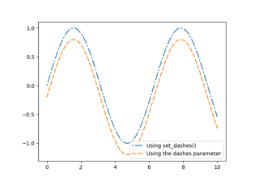

[Customizing dashed line styles](https://matplotlib.org/3.5.1/gallery/lines_bars_and_markers/line_demo_dash_control.html#sphx-glr-gallery-lines-bars-and-markers-line-demo-dash-control-py)

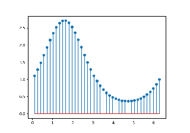

[Stem Plot](https://matplotlib.org/3.5.1/gallery/lines_bars_and_markers/stem_plot.html#sphx-glr-gallery-lines-bars-and-markers-stem-plot-py)

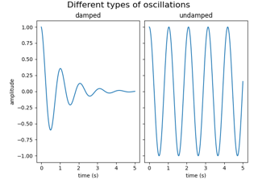

[Figure labels: suptitle, supxlabel, supylabel](https://matplotlib.org/3.5.1/gallery/subplots_axes_and_figures/figure_title.html#sphx-glr-gallery-subplots-axes-and-figures-figure-title-py)

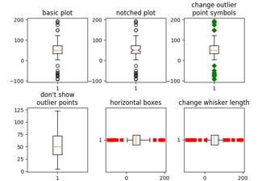

[Boxplots](https://matplotlib.org/3.5.1/gallery/statistics/boxplot_demo.html#sphx-glr-gallery-statistics-boxplot-demo-py)

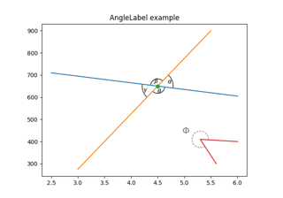

[Scale invariant angle label](https://matplotlib.org/3.5.1/gallery/text_labels_and_annotations/angle_annotation.html#sphx-glr-gallery-text-labels-and-annotations-angle-annotation-py)

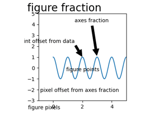

[Annotating Plots](https://matplotlib.org/3.5.1/gallery/text_labels_and_annotations/annotation_demo.html#sphx-glr-gallery-text-labels-and-annotations-annotation-demo-py)

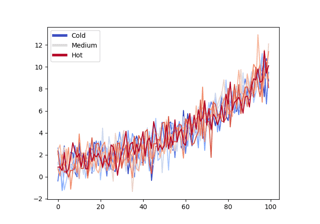

[Composing Custom Legends](https://matplotlib.org/3.5.1/gallery/text_labels_and_annotations/custom_legends.html#sphx-glr-gallery-text-labels-and-annotations-custom-legends-py)

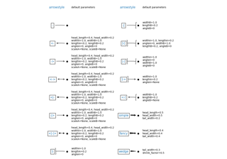

[Annotation arrow style reference](https://matplotlib.org/3.5.1/gallery/text_labels_and_annotations/fancyarrow_demo.html#sphx-glr-gallery-text-labels-and-annotations-fancyarrow-demo-py)

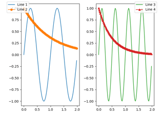

[Figure legend demo](https://matplotlib.org/3.5.1/gallery/text_labels_and_annotations/figlegend_demo.html#sphx-glr-gallery-text-labels-and-annotations-figlegend-demo-py)

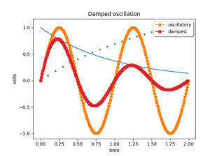

[Legend Demo](https://matplotlib.org/3.5.1/gallery/text_labels_and_annotations/legend_demo.html#sphx-glr-gallery-text-labels-and-annotations-legend-demo-py)

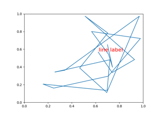

[Artist within an artist](https://matplotlib.org/3.5.1/gallery/text_labels_and_annotations/line_with_text.html#sphx-glr-gallery-text-labels-and-annotations-line-with-text-py)

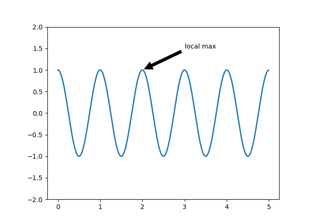

[Annotating a plot](https://matplotlib.org/3.5.1/gallery/pyplots/annotation_basic.html#sphx-glr-gallery-pyplots-annotation-basic-py)

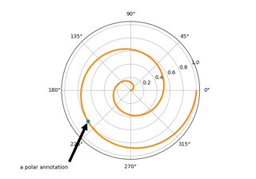

[Annotation Polar](https://matplotlib.org/3.5.1/gallery/pyplots/annotation_polar.html#sphx-glr-gallery-pyplots-annotation-polar-py)

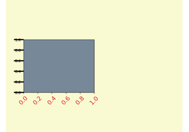

[Fig Axes Customize Simple](https://matplotlib.org/3.5.1/gallery/pyplots/fig_axes_customize_simple.html#sphx-glr-gallery-pyplots-fig-axes-customize-simple-py)

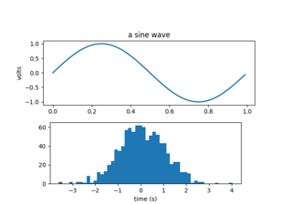

[Simple axes labels](https://matplotlib.org/3.5.1/gallery/pyplots/fig_axes_labels_simple.html#sphx-glr-gallery-pyplots-fig-axes-labels-simple-py)

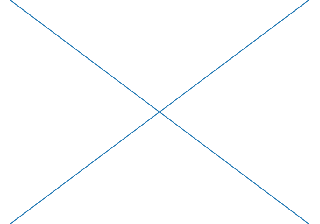

[Adding lines to figures](https://matplotlib.org/3.5.1/gallery/pyplots/fig_x.html#sphx-glr-gallery-pyplots-fig-x-py)

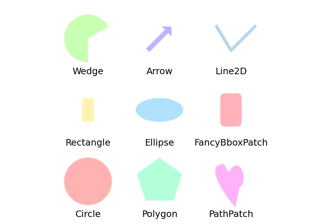

[Reference for Matplotlib artists](https://matplotlib.org/3.5.1/gallery/shapes_and_collections/artist_reference.html#sphx-glr-gallery-shapes-and-collections-artist-reference-py)

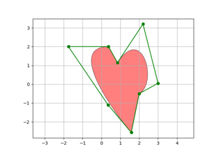

[PathPatch object](https://matplotlib.org/3.5.1/gallery/shapes_and_collections/path_patch.html#sphx-glr-gallery-shapes-and-collections-path-patch-py)

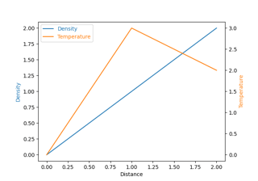

[Parasite Simple](https://matplotlib.org/3.5.1/gallery/axes_grid1/parasite_simple.html#sphx-glr-gallery-axes-grid1-parasite-simple-py)

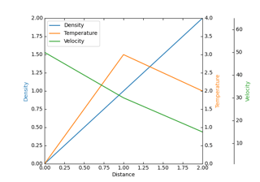

[Parasite Axes demo](https://matplotlib.org/3.5.1/gallery/axisartist/demo_parasite_axes.html#sphx-glr-gallery-axisartist-demo-parasite-axes-py)

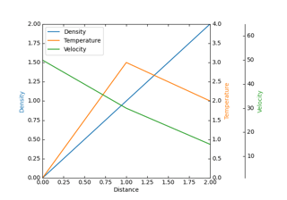

[Parasite axis demo](https://matplotlib.org/3.5.1/gallery/axisartist/demo_parasite_axes2.html#sphx-glr-gallery-axisartist-demo-parasite-axes2-py)

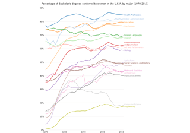

[Bachelor's degrees by gender](https://matplotlib.org/3.5.1/gallery/showcase/bachelors_degrees_by_gender.html#sphx-glr-gallery-showcase-bachelors-degrees-by-gender-py)

[figure not shown]

[Decay](https://matplotlib.org/3.5.1/gallery/animation/animate_decay.html#sphx-glr-gallery-animation-animate-decay-py)

[figure not shown]

[The double pendulum problem](https://matplotlib.org/3.5.1/gallery/animation/double_pendulum.html#sphx-glr-gallery-animation-double-pendulum-py)

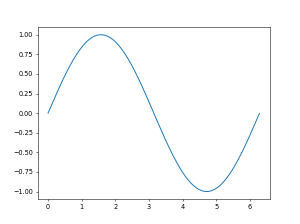

[Animated line plot](https://matplotlib.org/3.5.1/gallery/animation/simple_anim.html#sphx-glr-gallery-animation-simple-anim-py)

[figure not shown]

[Oscilloscope](https://matplotlib.org/3.5.1/gallery/animation/strip_chart.html#sphx-glr-gallery-animation-strip-chart-py)

[figure not shown]

[MATPLOTLIB UNCHAINED](https://matplotlib.org/3.5.1/gallery/animation/unchained.html#sphx-glr-gallery-animation-unchained-py)

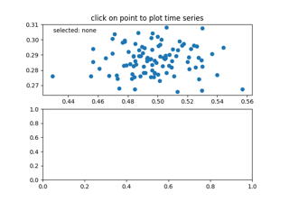

[Data Browser](https://matplotlib.org/3.5.1/gallery/event_handling/data_browser.html#sphx-glr-gallery-event-handling-data-browser-py)

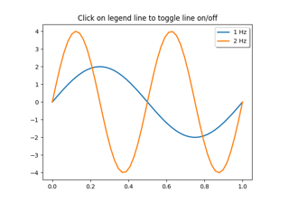

[Legend Picking](https://matplotlib.org/3.5.1/gallery/event_handling/legend_picking.html#sphx-glr-gallery-event-handling-legend-picking-py)

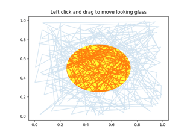

[Looking Glass](https://matplotlib.org/3.5.1/gallery/event_handling/looking_glass.html#sphx-glr-gallery-event-handling-looking-glass-py)

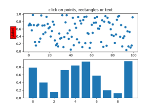

[Pick Event Demo](https://matplotlib.org/3.5.1/gallery/event_handling/pick_event_demo.html#sphx-glr-gallery-event-handling-pick-event-demo-py)

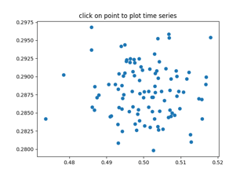

[Pick Event Demo2](https://matplotlib.org/3.5.1/gallery/event_handling/pick_event_demo2.html#sphx-glr-gallery-event-handling-pick-event-demo2-py)

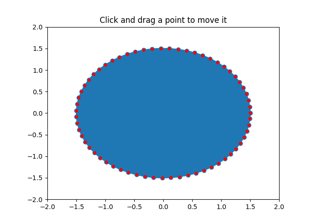

[Poly Editor](https://matplotlib.org/3.5.1/gallery/event_handling/poly_editor.html#sphx-glr-gallery-event-handling-poly-editor-py)

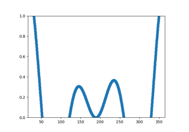

[Resampling Data](https://matplotlib.org/3.5.1/gallery/event_handling/resample.html#sphx-glr-gallery-event-handling-resample-py)